# Lousville Dockless Vehicles: Exploratory Data Analysis

Luca Baggi

# Load packages

```r
library(tidyverse)
library(tidymodels)

# for enhancing ggplot
library(ggridges)
library(ggthemes)
  # set a theme to stay for the rest of the plotting
  theme_set(theme_fivethirtyeight())
```

# Load data

```r
trips <-
  read_csv(
    'data/escooters_od.csv',
    col_types = cols(
      StartTime = col_datetime(format = '%Y-%m-%d %H:%M:%S'),
      EndTime = col_datetime(format = '%Y-%m-%d %H:%M:%S')
    )
  ) %>%
  mutate(
    Duration = as.integer(Duration),
    # convert in meters
    Distance = as.integer(round(Distance * 1609)),
    # turn into factors
    StartNH = as.factor(StartNH),
    EndNH = as.factor(EndNH),
    # rename TripID
    TripID = 1:length(TripID),
    # add a dummy for short trip (with short duration and distance)
    ShortTrip = as.factor(ifelse((Duration <= 1 | Distance <= 100), 1, 0)),
    # first covid death reported is on March 21st, 2020
    Covid = as.factor(ifelse(StartTime > '2020-03-20 23:59:59', 1, 0))
  ) %>%
  as_tibble()

trips %>% head()
```

| TripID | Duration | Distance | StartLatitude | StartLongitude | StartTime | StartNH | EndLatitude | EndLongitude | EndTime | EndNH | ShortTrip | Covid |
| --- | --- | --- | --- | --- | --- | --- | --- | --- | --- | --- | --- | --- |
| 1 | 3 | 0 | 38.253 | -85.756 | 2019-06-26 19:30:00 | Downtown | 38.253 | -85.755 | 2019-06-26 19:30:00 | Downtown | 1 | 0 |
| 2 | 5 | 0 | 38.203 | -85.752 | 2019-09-22 14:30:00 | University | 38.204 | -85.751 | 2019-09-22 14:30:00 | University | 1 | 0 |
| 3 | 6 | 531 | 38.259 | -85.733 | 2019-08-21 17:30:00 | Downtown | 38.265 | -85.739 | 2019-08-21 17:30:00 | Northeast Core | 0 | 0 |
| 4 | 6 | 1030 | 38.217 | -85.757 | 2019-07-03 11:00:00 | University | 38.221 | -85.763 | 2019-07-03 11:15:00 | West Core | 0 | 0 |
| 5 | 7 | 964 | 38.215 | -85.759 | 2019-11-22 10:45:00 | University | 38.222 | -85.764 | 2019-11-22 11:00:00 | West Core | 0 | 0 |
| 6 | 7 | 1101 | 38.221 | -85.762 | 2019-05-04 21:15:00 | University | 38.223 | -85.764 | 2019-05-04 21:30:00 | University | 0 | 0 |

Two features have been added:

```r
trips %>%
  count(ShortTrip) %>%
  mutate(count = n/sum(n))
```

| ShortTrip | n | count |
| --- | --- | --- |
| 0 | 421509 | 0.7822817 |
| 1 | 117311 | 0.2177183 |

```r
trips %>%
  count(Covid) %>%
  mutate(count = n/sum(n))
```

| Covid | n | count |
| --- | --- | --- |
| 0 | 513501 | 0.95301028 |
| 1 | 25319 | 0.04698972 |

Only some 25.000 trips happened during COVID-19 emergency.

# Boxplot

## Boxplot as it is

To obtain a first impression:

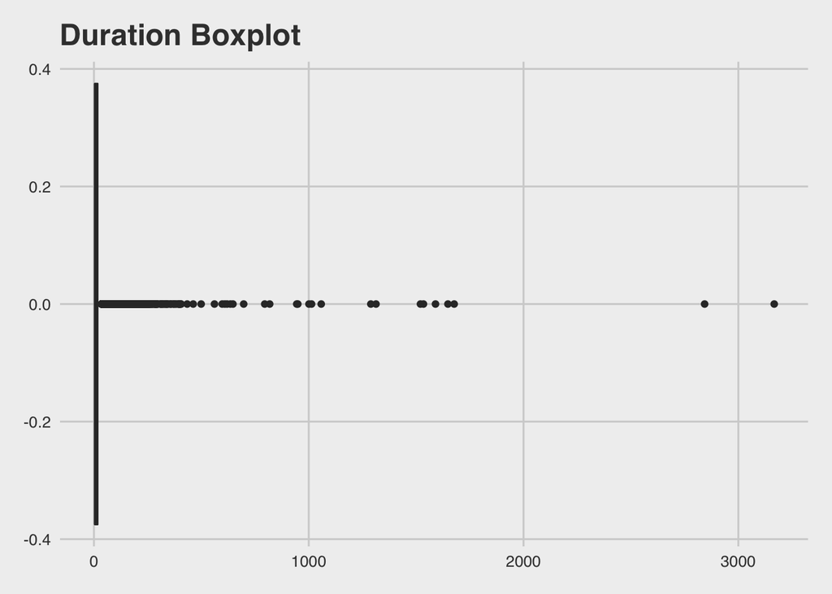

```r
trips %>%
  ggplot(aes(x = Duration)) +
  geom_boxplot() +
  ggtitle('Duration Boxplot')
```

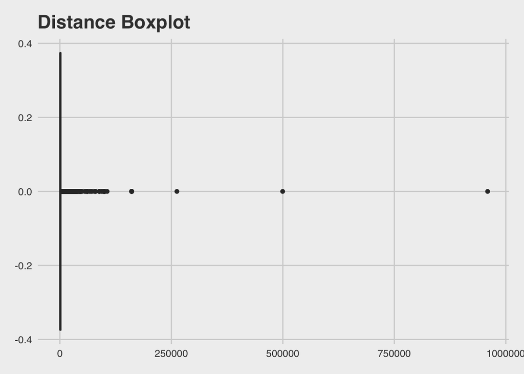

```r
trips %>%
  ggplot(aes(x = Distance)) +
  geom_boxplot() +
  ggtitle('Distance Boxplot')
```

There are way to many outliers: we can’t see anything!

## Create a Filter

Note that there are some values of distance which are negative: we should also deal with them.

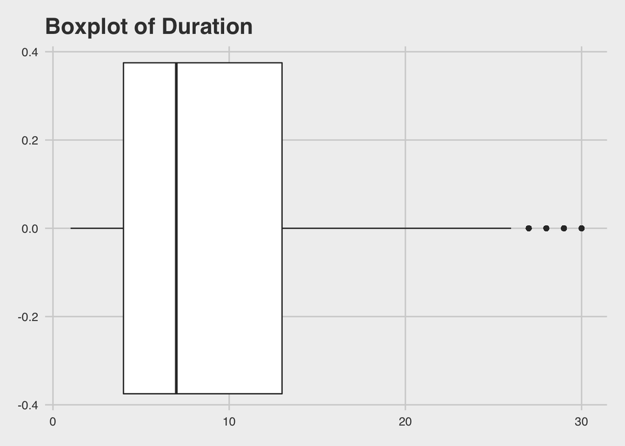

```r
trips_filter <-
  trips %>%
  filter(
    # Duration between 0 and 30 minutes
    Duration > 0 & Duration <= 30 &
    # Distance between 0 and 5km
    Distance > 0 & Distance <= 5000
  )

trips_filter %>%
  ggplot(aes(x = Duration)) +
  geom_boxplot() +
  ggtitle('Boxplot of Duration')
```

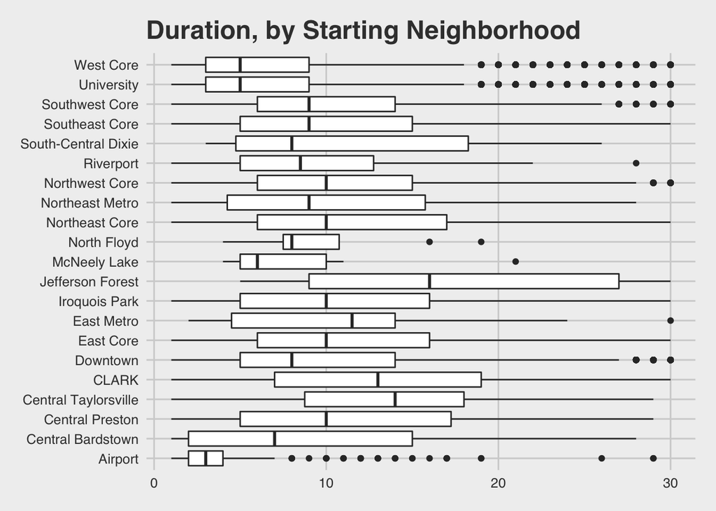

```r
trips_filter %>%
  ggplot(aes(x = Duration, y = StartNH)) +
  geom_boxplot() +
  ggtitle('Duration, by Starting Neighborhood')
```

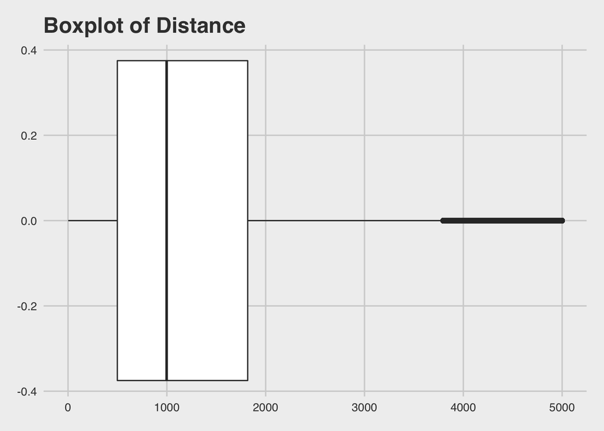

```r
trips_filter %>%
  ggplot(aes(x = Distance)) +
  geom_boxplot() +
  ggtitle('Boxplot of Distance')
```

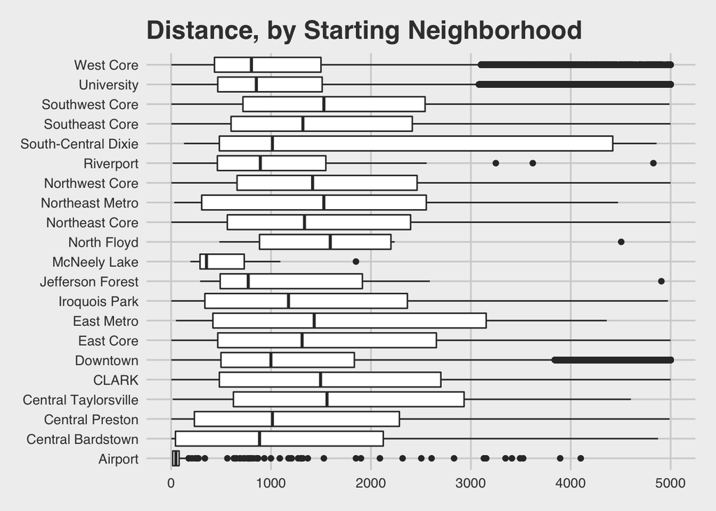

```r
trips_filter %>%
  ggplot(aes(x = Distance, y = StartNH)) +
  geom_boxplot() +
  ggtitle('Distance, by Starting Neighborhood')
```

Filtering is almost always arbitrary. Here we are not conservative at all especially because we are left nonetheless with more than 350.000 observations - a real challenge for our hardware to process!

However, there are theoretical reasons behind this nonetheless: trips lasting longer than half an hour seem suspicious - we would need idle time to make a more thorough analysis. The `distance` threshold is not varying very much: only some 10.000 observations get eliminated. This will result in cleaner histograms.

This will indeed underrepresent trips from the outermost neighbourhoods, but we would delete most of these regardless.

## Pivot Long Boxplot

But this on its own is not really informing: what can we say about the underlying distribution?

Let’s pivot to a longer table:

```r
trips_long <-
  trips_filter %>%
  # select only the rows we need
  select(TripID, Duration, Distance, StartNH, EndNH, Covid, ShortTrip) %>%
  # change all factors in integers, otherwise the pivot fails
  # using across() + where() instead of mutate_if, as lifecycle is superseded:
  mutate(across(where(is.factor), as.integer)) %>%
  # pivot to longer:
  pivot_longer(
    # spec the col we want to leave as it is:
    cols = !TripID,
    # define the name of the 'supercolumn' with the classes:
    names_to = 'Class',
    # define the name of the column with all the values:
    values_to = 'Values'
  )

trips_long %>%
  head()
```

| TripID | Class | Values |
| --- | --- | --- |
| 3 | Duration | 6 |
| 3 | Distance | 531 |
| 3 | StartNH | 6 |
| 3 | EndNH | 14 |
| 3 | Covid | 1 |
| 3 | ShortTrip | 1 |

Then we can create some better plots:

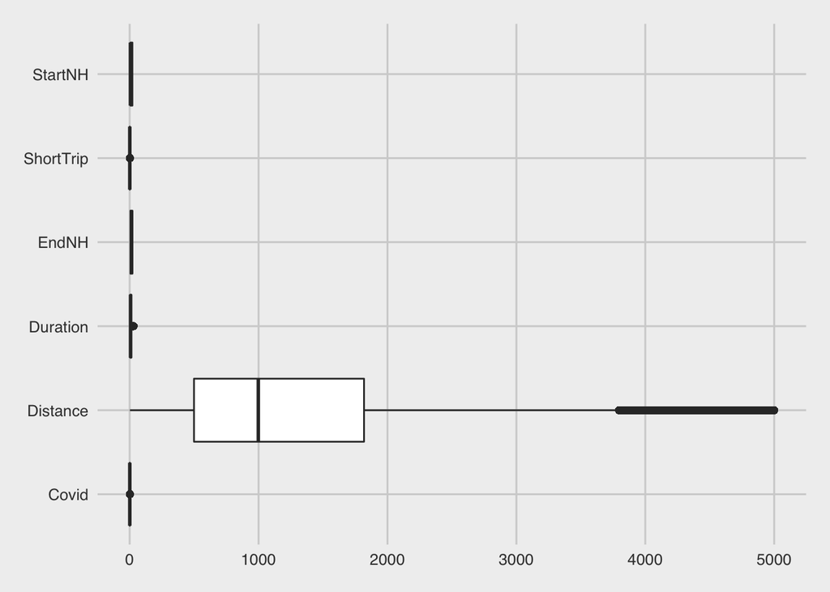

```r
trips_long %>%
  ggplot(aes(Values, Class)) +
  geom_boxplot()
```

Of course, these are not very informative: `Distance` is so broad that in comparison all other values shrink. Also, binary factors are pretty useless in a boxplot! To obtain more info, now, we may want to look at histogram and ridges.

# Histograms

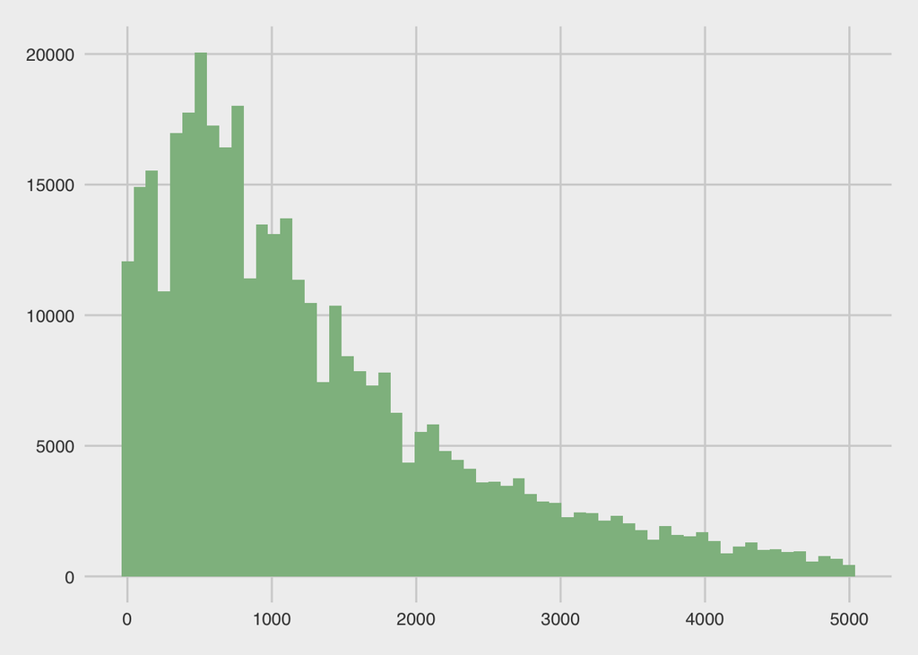

```r
trips_filter %>%
  ggplot(aes(x = Distance)) +
  geom_histogram(fill = 'darkseagreen', bins = 60)
```

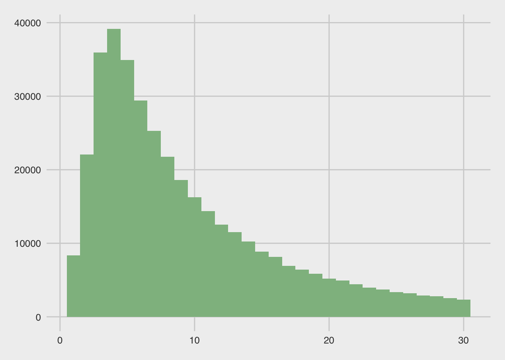

```r
trips_filter %>%
  ggplot(aes(x = Duration)) +
  geom_histogram(fill = 'darkseagreen', bins = 30)
```

But on their own these aren’t very informative. We might want to see if COVID-19 has any effects:

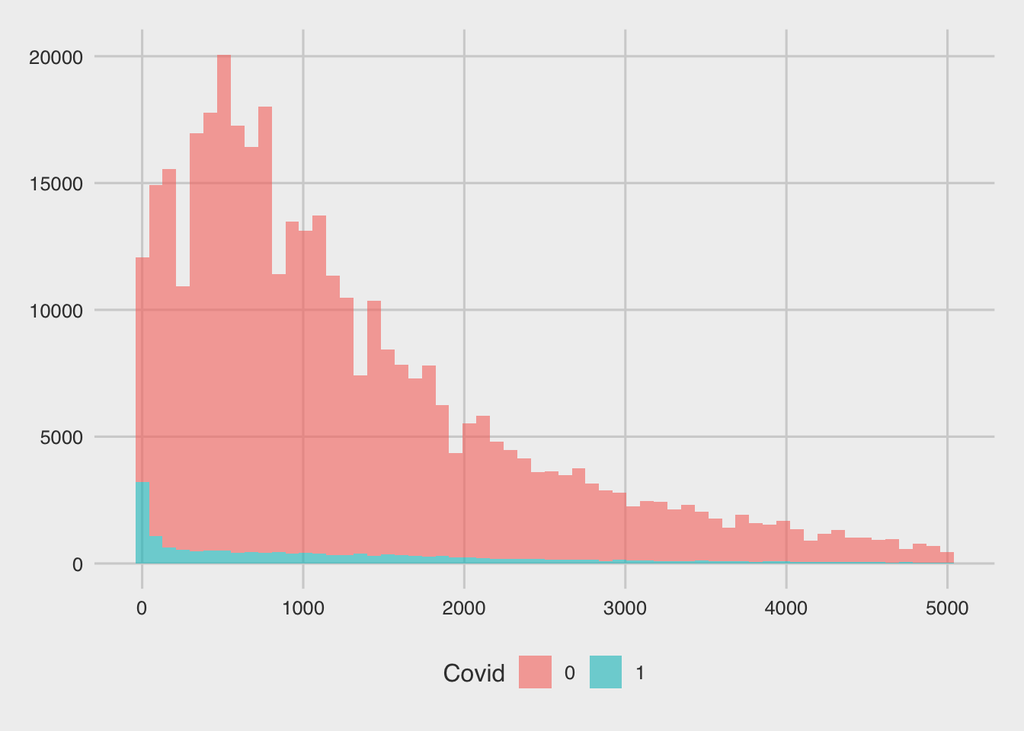

```r
trips_filter %>%
  ggplot(aes(x = Distance, fill = Covid)) +
  geom_histogram(bins = 60, alpha = 0.6)
```

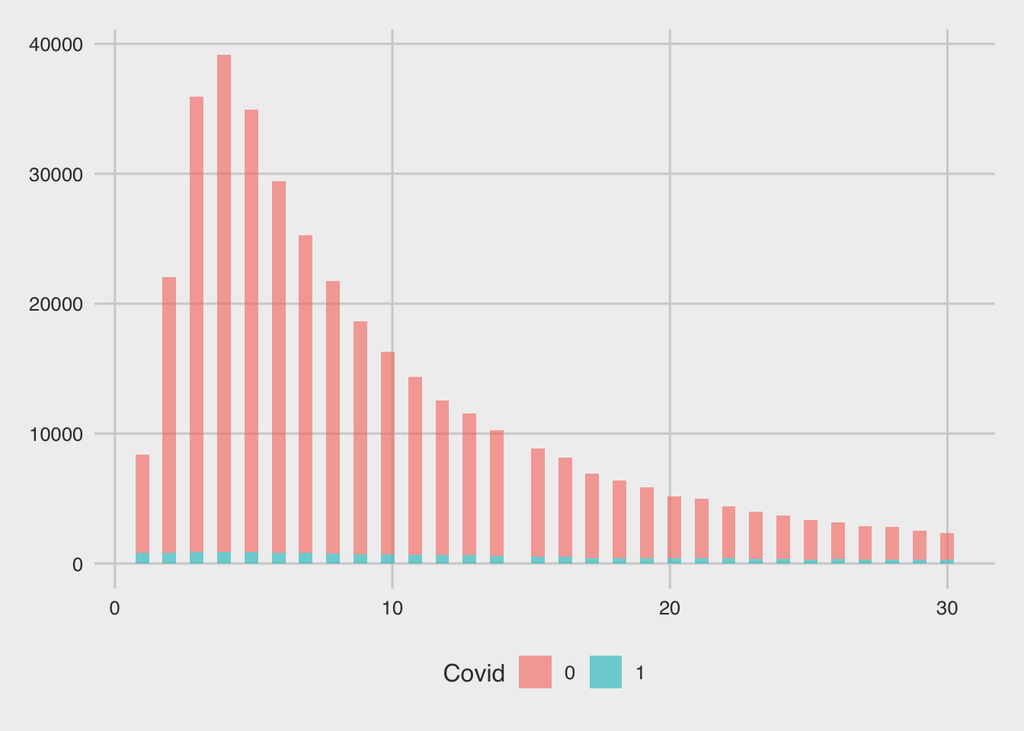

```r
trips_filter %>%
  ggplot(aes(x = Duration, fill = Covid)) +
  geom_histogram(bins = 60, alpha = 0.6)
```

It turns out, this does not tell very much!

# Ridges

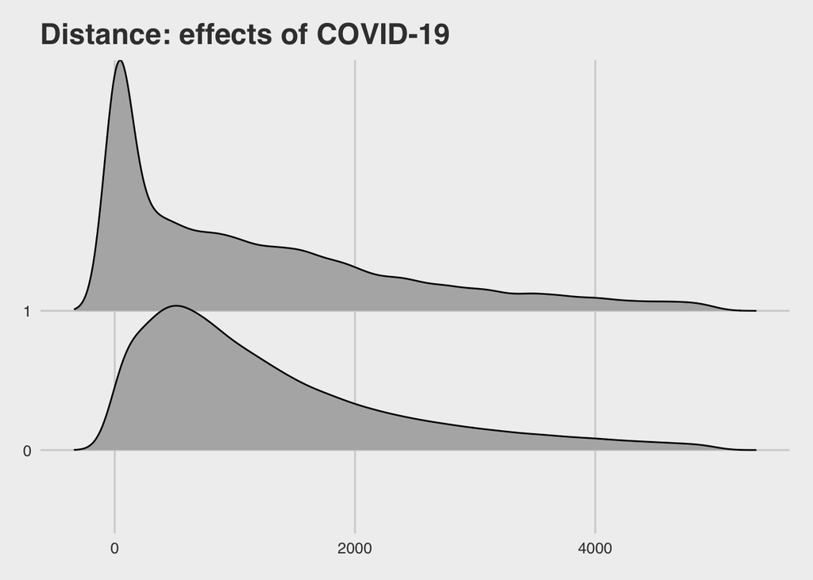

```r
trips_filter %>%
  ggplot(aes(x = Distance, y = Covid)) +
  geom_density_ridges() +
  ggtitle('Distance: effects of COVID-19') +
  ylab('0: no COVID-19')
```

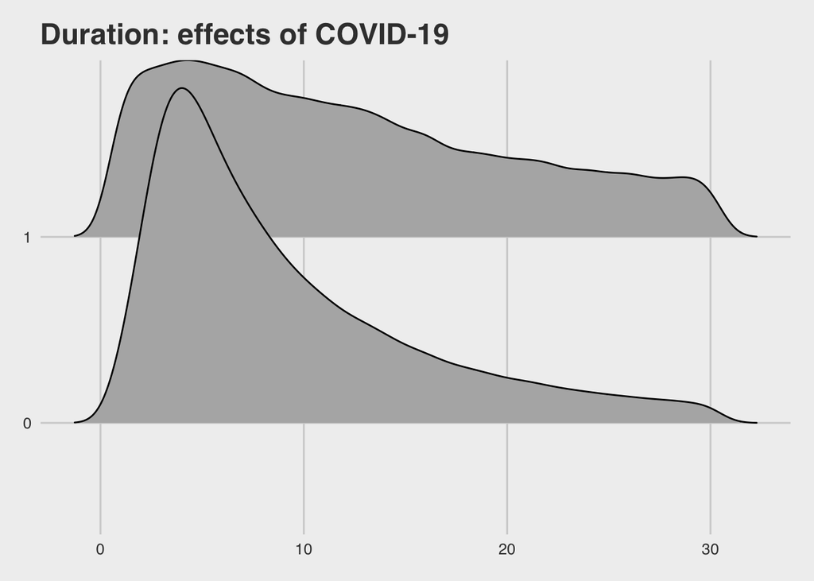

```r
trips_filter %>%
  ggplot(aes(x = Duration, y = Covid)) +
  geom_density_ridges() +
  ggtitle('Duration: effects of COVID-19') +
  ylab('0: no COVID-19')
```